# 02_initial_plots

```r
library(tidyverse)
```

# Data Review

All the data used for analyis:

### Average Monthly Discharge

```r
avg_monthly_discharge <- read.csv("../clean_data/avg_monthly_discharge.txt")
avg_monthly_discharge <- avg_monthly_discharge %>% rename("1" = X1, "2" = X2, "3" = X3, "4" = X4, "5" = X5, "6" = X6, "7" = X7, "8" = X8, "9" = X9, "10" = X10, "11" = X11, "12" = X12)
head(avg_monthly_discharge)
```

```
##   year     1     2     3     4     5     6     7     8     9    10    11
## 1 1941 10310  8654  8487 11080 15880 14970  9820  6441 11450 17330 13860
## 2 1942  7636  7626  6856 11510 16870 25400 17230  8373  5023  4323 13380
## 3 1943 11730 11970 11600 23360 21660 31420 29840 11430  7183  8100  6592
## 4 1944  9965  8044  7878 10610 17400 19620 10430  6835  9945  8736 10810
## 5 1945 15950 14860  9714 10130 25960 25370 16170  8083  8469 14340 17990
## 6 1946 13670 10680 12820 16580 36530 32810 23750 10590  6745  8957  9351
##      12
## 1 20490
## 2 15710
## 3 10670
## 4 10930
## 5 12540
## 6 18200
```

### Daily Average Discharge

```r
avg_daily_discharge <- read.csv("../data/avg_daily_discharge.csv")
head(avg_daily_discharge)
```

```
##   month day day.of.year  mean
## 1     1   1           1 15600
## 2     1   2           2 15600
## 3     1   3           3 16600
## 4     1   4           4 16800
## 5     1   5           5 17700
## 6     1   6           6 17700
```

### Steelhead Smolt Trapped per Year

```r
yearly_smolt <- read.csv("../data/steelhead_smolt_trapped.csv")
head(yearly_smolt)
```

```
##   year smolt..screw. smolt..scoop.
## 1 1990            na           198
## 2 1991            na           301
## 3 1992            na           332
## 4 1993           663           304
## 5 1994          1297           601
## 6 1995          1184           532
```

# Average Hydrograph

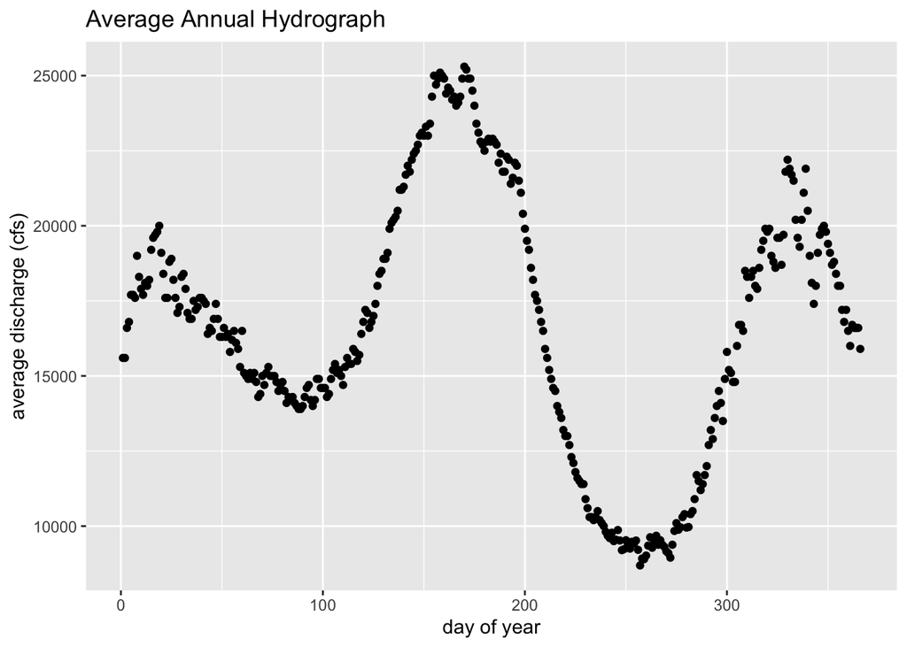

```r
ggplot(avg_daily_discharge)+
  geom_point(mapping = aes(x=day.of.year, y=mean))+
  labs(x="day of year", y= "average discharge (cfs)", title = "Average Annual Hydrograph")
```

The plot uses the average discharge for each day with data from 1940 to 2018. Each point represents the average discharge in cubic feet per second for that specific day of the year.

Peaks around May and November/December indicate watershed dominated by both rain and snow. Spring peak around May and into June originates from snow melt at higher elevations as temperatures rise with the season.

# Late Spring Discharge

| may | june | year | late_spring |
| --- | --- | --- | --- |
| 15880 | 14970 | 1941 | 30850 |
| 16870 | 25400 | 1942 | 42270 |
| 21660 | 31420 | 1943 | 53080 |
| 17400 | 19620 | 1944 | 37020 |
| 25960 | 25370 | 1945 | 51330 |

This creates a new table with just the average monthly discharges for may and june as well as a sum for the two months. May and June are the peak of the snow melt discharge of spring so this table provides the data to analyze that peak.

# Late Spring Discharge vs Smolt Outmigration

```r
discharge_and_smolt <- inner_join(late_spring_discharge,
                                  yearly_smolt, by = "year")
```

| may | june | year | late_spring | smolt..screw. | smolt..scoop. |
| --- | --- | --- | --- | --- | --- |
| 17460 | 24930 | 1990 | 42390 | na | 198 |
| 20860 | 22150 | 1991 | 43010 | na | 301 |
| 16010 | 13430 | 1992 | 29440 | na | 332 |
| 22900 | 18050 | 1993 | 40950 | 663 | 304 |

The code here joins the late spring discharge table and the smolt outmigration table for analysis.

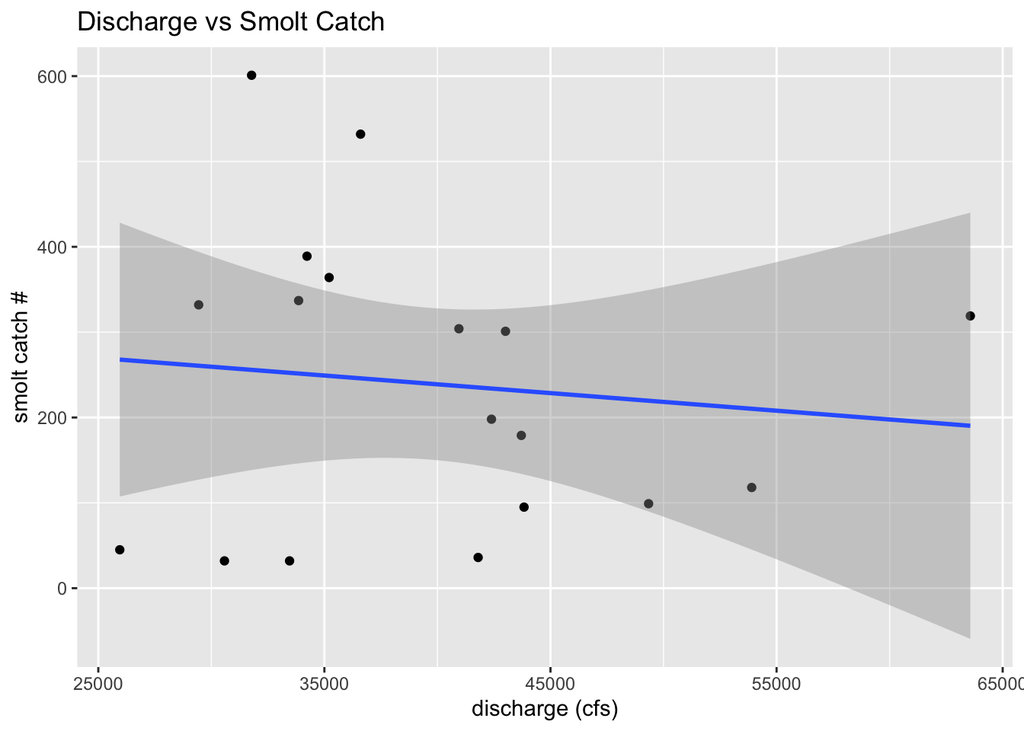

This code plots smolt outmigration as a function of late spring discharge. It also ncludes trendline to indicate a potential relationship between smolt outmigration and higher spring discharges.

```
##
## Call:
## lm(formula = smolt..scoop. ~ late_spring, data = discharge_and_smolt)
##
## Residuals:
##     Min      1Q  Median      3Q     Max
## -226.29 -132.15   15.56  107.80  345.18
##
## Coefficients:
##               Estimate Std. Error t value Pr(>|t|)
## (Intercept) 321.301397 187.157316   1.717    0.105
## late_spring  -0.002061   0.004601  -0.448    0.660
##
## Residual standard error: 177.9 on 16 degrees of freedom
## Multiple R-squared:  0.01238,    Adjusted R-squared:  -0.04935
## F-statistic: 0.2006 on 1 and 16 DF,  p-value: 0.6603
```

A linear regression model here finds no relationship between smolt outmigration and late spring discharge.

# Potential Climate Change Analysis

In the interest of future research, this study also looked at the changes in late spring discharge over time and the potential effects of climate change.

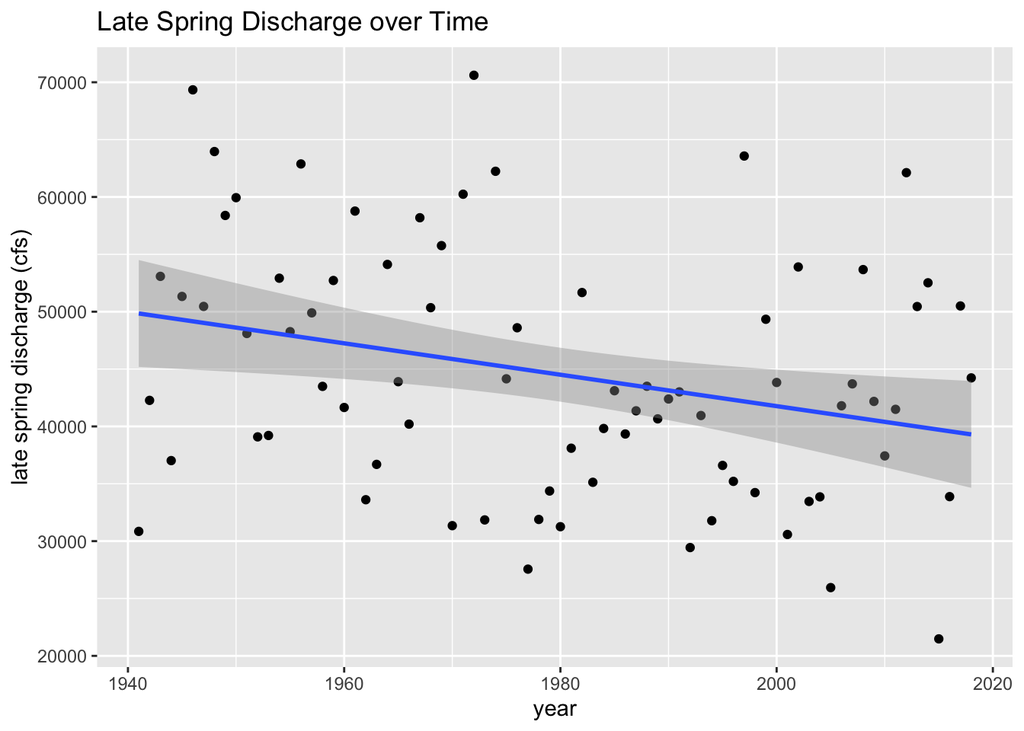

```
##
## Call:
## lm(formula = late_spring ~ year, data = late_spring_discharge)
##
## Residuals:
##      Min       1Q   Median       3Q      Max
## -18995.9  -7718.5   -544.2   7432.3  25008.5
##
## Coefficients:
##              Estimate Std. Error t value Pr(>|t|)
## (Intercept) 315603.33  103794.65   3.041  0.00324 **
## year          -136.92      52.43  -2.611  0.01086 *
## ---
## Signif. codes:  0 '***' 0.001 '**' 0.01 '*' 0.05 '.' 0.1 ' ' 1
##
## Residual standard error: 10430 on 76 degrees of freedom
## Multiple R-squared:  0.08234,    Adjusted R-squared:  0.07026
## F-statistic: 6.819 on 1 and 76 DF,  p-value: 0.01086
```

# Future Research

More data on a shorter timescale

- More years of smolt catch (2007-present)
- Weekly/daily catch numbers

Threat of climate change

- important to understand relationship
- Timing/intensity of discharge likely to change

# Challenges

- Importing data without commas
- Resizing images to fit in the presentation
- Completing and displaying results of linear regression
- Pulling correct columns for analysis tables